# Logistic Growth Model

Nik Seldon

4/1/2020

### Deviation from Exponential Growth

In the previous analysis [previous analysis](https://nikseldon.github.io/COVID-19-Analysis/) an exponential law of growth is used to describe the dynamik of COVID-19 outbreak in europe. This is an approximation that can be used in the case of an unlimited growth. One limitation for the growth of an outbreak is the fact that, as there are more and more people get infected, they become immune and can’t be infected anymore. Thus the incremental number of daily new cases is decreasing. It is expected that for COVID-19 the spread stopps or decreases substantial, when a fraction $(1-1/R_0)$ of population is/was infected. R_0 =2…3 denotes the basic reproduction number. We can assume that we are still far away from the point where around 60% of the population is infected, even though an increasing amount of infected people can not be tested as the desease is spreading further. Thus, if we observe this deviation from an exponential growth these days, the reasons might be

- measures of social distancing and quarantine
- clusters of infections in certain regions with higher fractions of infected person
- a capacity limit in testing people, that results in a increasing discrepancy between the true number of infected people and the confirmed cases.

The following figure shows the cumulative number of confirmed cases and the deviation from an exponential growth for Germany:

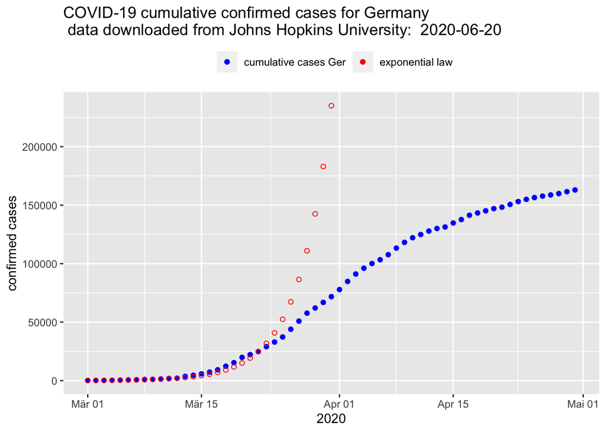

### Applying the Logistic Growth Model (Gompertz-function)

We can account of a limited growth by applying a logistic growth model. Here the growth is being slowest at the onset and at the end of the epidemic. It is considered in the model, that the number of infections approaches a maximum value ($N_{max}$) and that the growth rate $\mu$ decreases as N increases.

We than have two differential equations:

- $d\mu/dt=-k\mu$
- $dN/dt=\mu N$ with an analytical Solution (Gompertz-equation):
- $N=N_0*e^{\mu_0/k*(1-e^{-kt})}$ , where $\mu_0=k*ln(N_{max}/N_0)$ is the initial growth rate

The Gompertz function is used here, as it represents a asymetrical version of the logistic growth model. The epidemic curve of a “point source outbreak” can be described by the log-normal-distribution, there is a rapid increase of cases and a rather slow decrease. The cummulative amount of cases then yields this asymmetrical growth - function. The model is an estimation as many others, it may estimate the near future of disease development with respect to the current conditions.

https://en.wikipedia.org/wiki/Gompertz_function

### Nonlinear Least Square (NLS) FIT

A NLS model is used to determine the parameters $N_{max}$ and $k$, the maximum number of infections and the growth rate, respectively.

```r
#initial value
N0<-fitGER$cumulative_cases[1]
#estimate for Nmax:
mu<-0.25
d=50
Nmax=N0+exp(mu*d)
k<-0.5
#Gompertz function
f<-function(t,Nmax,k){N0*exp(log(Nmax/N0)*(1-exp(-k*t)))}
mydata<-list(t=as.numeric(fitGER$time), y=fitGER$cumulative_cases)
pstart<-list(Nmax=Nmax,k=k)
aFitGER<-nls(y~f(t,Nmax,k), data=mydata, start=pstart, trace=TRUE)
```

```
## 2.015925e+12 :  268467.3      0.5
## 154702340700 :  9.009285e+04 3.007999e-01
## 70367190981 :  9.605800e+04 1.133783e-01
## 51122104078 :  1.270941e+05 6.930264e-02
## 1323898255 :  1.899297e+05 6.581254e-02
## 940616282 :  1.886355e+05 6.769734e-02
## 939368042 :  1.892975e+05 6.753303e-02
## 939362442 :  1.892586e+05 6.754711e-02
## 939362406 :  1.892620e+05 6.754598e-02
## 939362405 :  1.892617e+05 6.754607e-02
```

```r
summary(aFitGER)
```

```
##
## Formula: y ~ f(t, Nmax, k)
##
## Parameters:
##       Estimate Std. Error t value Pr(>|t|)
## Nmax 1.893e+05  2.360e+03   80.19   <2e-16 ***
## k    6.755e-02  7.242e-04   93.27   <2e-16 ***
## ---
## Signif. codes:  0 '***' 0.001 '**' 0.01 '*' 0.05 '.' 0.1 ' ' 1
##
## Residual standard error: 3990 on 59 degrees of freedom
##
## Number of iterations to convergence: 9
## Achieved convergence tolerance: 1.358e-06
```

### Prediction

```r
times<-seq(0,120,1)
predGER<-predict(aFitGER, list(t=times))
predGER<-tibble(time=times, cumulative_cases=predGER)%>%
  mutate(date=time+ymd("2020-03-01"))%>%
  mutate(incident_cases = c(0, diff(cumulative_cases)))
```

#### Plots

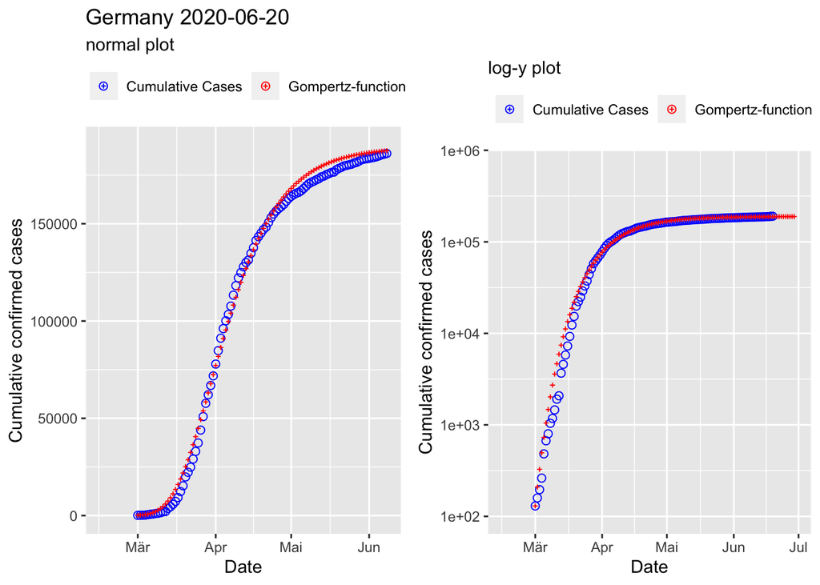

```r
title=paste(country, dateDownloaded)
require(gridExtra)
p1<-ggplot()+
  geom_point(data=dataGER, aes(x = Date, y = cumulative_cases, color="Cumulative Cases"), pch=21, cex=2)+
  geom_point(data=predGER, aes(x=date, y=cumulative_cases, color="Gompertz-function"), pch=3, cex=.5)+
  labs(y = "Cumulative confirmed cases", title =title, subtitle = "normal plot") +
  xlim(c(as.Date('2020-02-15 00:00:00', format = "%Y-%m-%d %H:%M:%S"),
         as.Date('2020-06-08 00:00:00', format = "%Y-%m-%d %H:%M:%S")))+
  scale_color_manual(values = c("Cumulative Cases"="blue", "Gompertz-function"="red"))+
  theme(legend.position = "top", legend.title = element_blank())

p2<-ggplot()+
  geom_point(data=dataGER, aes(x = Date, y = cumulative_cases, color="Cumulative Cases"), pch=21, cex=2)+
  geom_point(data=predGER, aes(x=date, y=cumulative_cases, color="Gompertz-function"), pch=3, cex=.5)+
  labs(y = "Cumulative confirmed cases",title =" \n ", subtitle = "log-y plot") +
  scale_color_manual(values = c("Cumulative Cases"="blue", "Gompertz-function"="red"))+
  xlim(c(as.Date('2020-02-15 00:00:00', format = "%Y-%m-%d %H:%M:%S"),
         as.Date('2020-06-30 00:00:00', format = "%Y-%m-%d %H:%M:%S")))+
  scale_y_log10(limits = c(100,6.5e5))+
  theme(legend.position = "top", legend.title = element_blank())

grid.arrange(p1,p2,ncol=2)
```

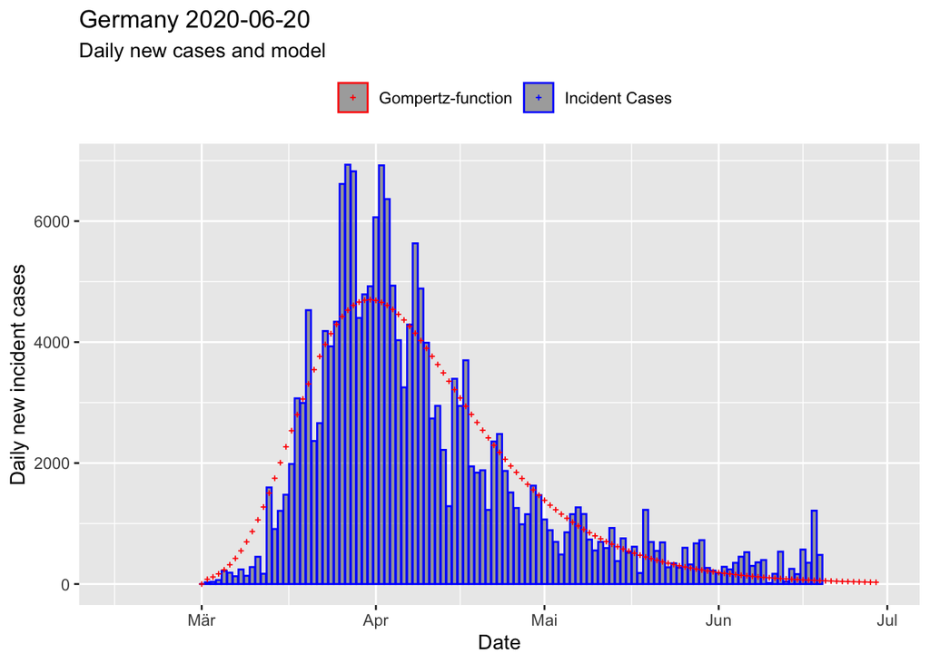

```r
title<-paste(country, dateDownloaded)
ggplot()+
  geom_col(data=dataGER, aes(x = Date, y = incident_cases, color="Incident Cases"), alpha=0.5)+
  geom_point(data=predGER, aes(x=date, y=incident_cases, color="Gompertz-function"), pch=3, cex=.5)+
  labs(y = "Daily new incident cases", title =title, subtitle = "Daily new cases and model") +xlim(c(as.Date('2020-02-15 00:00:00', format = "%Y-%m-%d %H:%M:%S"),
         as.Date('2020-06-30 00:00:00', format = "%Y-%m-%d %H:%M:%S")))+
  scale_color_manual(values = c("Incident Cases"="blue", "Gompertz-function"="red"))+
  theme(legend.position = "top", legend.title = element_blank())
```

### Switzerland

```
## 3275905621 :  5e+04 7e-02
## 104048936 :  3.113202e+04 7.602970e-02
## 27560515 :  3.209009e+04 7.894646e-02
## 27483589 :  3.219765e+04 7.863719e-02
## 27483122 :  3.219049e+04 7.866122e-02
## 27483119 :  3.219109e+04 7.865943e-02
## 27483119 :  3.219104e+04 7.865956e-02
```

```
##
## Formula: y ~ f(t, Nmax, k)
##
## Parameters:
##       Estimate Std. Error t value Pr(>|t|)
## Nmax 3.219e+04  2.836e+02   113.5   <2e-16 ***
## k    7.866e-02  7.361e-04   106.9   <2e-16 ***
## ---
## Signif. codes:  0 '***' 0.001 '**' 0.01 '*' 0.05 '.' 0.1 ' ' 1
##
## Residual standard error: 682.5 on 59 degrees of freedom
##
## Number of iterations to convergence: 6
## Achieved convergence tolerance: 1.781e-06
```

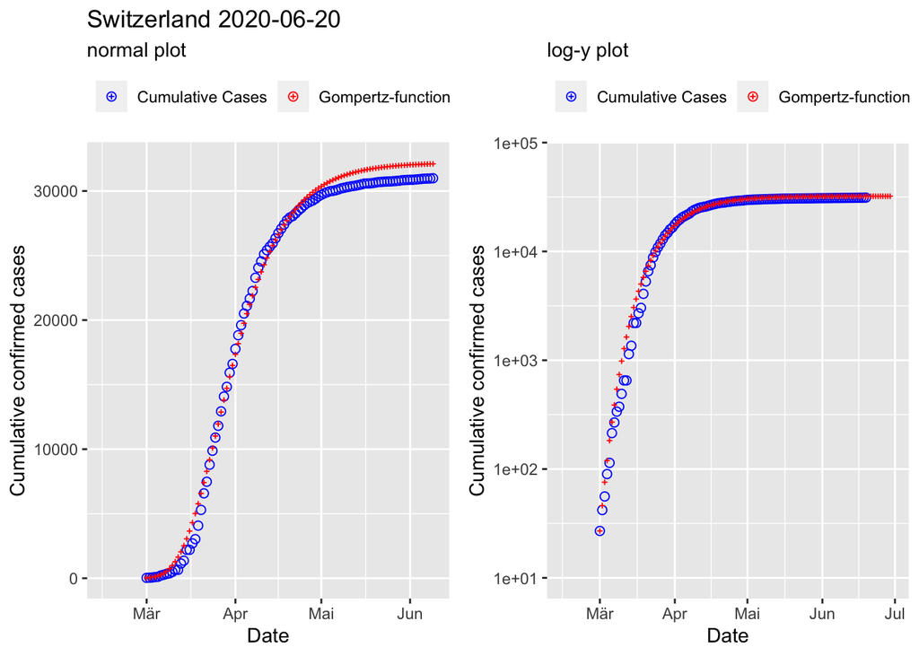

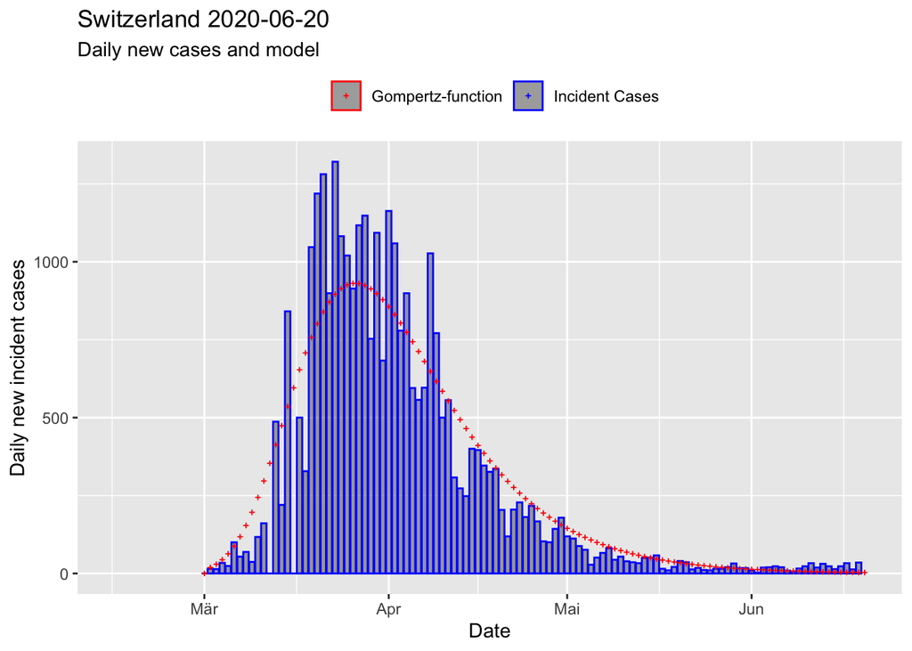